# Tennis

Michael Roberts, Min Liu, Nicholas Hovens, Zhexu Zhang

6 May 2019

## Introduction

**Team members:** Michael Roberts, Min Liu, Nicholas Hovens, Zhexu Zhang

### What is tennis

[interactive chart not shown]

[via GIPHY](https://giphy.com/gifs/l378nQAeexVYyjqs8)

- tennis is a racket sport
- can be played individually against a single opponent or between two teams of two players each
- each player uses the racket to hit the tennis ball over the net to their opponents side of the court
- the object of the game is to hit the ball in such a way that the opponent cannot play a valid return
- the player who plays the winning shot gets a point

### About our data

- we used the “deuce” package to obtain our data https://github.com/skoval/deuce

## Australian Men’s ATP Rankings

- The ATP rankings are used by the Association of Tennis Professionals (ATP) to determine qualification for entry as well as the seeding of players in all singles and doubles tournaments
- The rankings are updated every Monday, so I have used the first Monday of every year from 2001 - 2018 for the following analysis
- I will be focusing on the singles rankings

### Cleaning of the data

```r
atp_players1 <- atp_players %>%
 select(name, player_id, country_code)%>%
 filter(country_code == "AUS")

atp_rankings1 <- atp_rankings %>%
 select(ranking, player_id, date)%>%
 filter(ranking <= 100)

atp_data <- atp_players1 %>%
  left_join(atp_rankings1, by = "player_id") %>%
  mutate(year = year(date),
         day = day(date),
         month = month(date, label=TRUE, abbr=TRUE))#, locale = "English"))

current_atprankings <- fetch_atp_rankings("2019-05-20", min_rank = 1, max_rank = 100) %>%
 select(player, rank, date) %>%
  rename(c("player" = "name", "rank" = "ranking"))

currentatp_data <- atp_players1 %>%
  full_join(current_atprankings, by = "name") %>%
  na.omit(currentatp_data)
```

- the atp_players data was read in, relevant variables were selected and the country was filtered to display only Australian players
- the atp_rankings data was read in, the relevant variables were selected and the rankings were filtered to show the top 100
- the atp players and atp rankings data was then combined via a left join so that the rankings can be attributed to name
- the date of the rankings was also split into 3 variables: year, month and day
- the same was done for the current ATP rankings (fetch_atp_rankings), a couple of the variables were renamed so they could be joined to the atp_players data and the NA values were omitted

### Individual Australian players ATP rankings

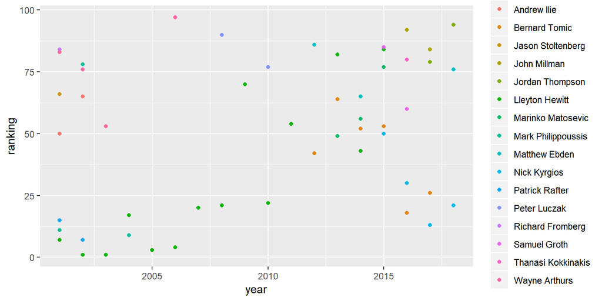

[interactive chart not shown]

[via GIPHY](https://giphy.com/gifs/usopen-tennis-us-open-3otPoF2hzMGINMhMNa)

- We have had at least 1 player ranked in the top 100 each year since 2001
- We have had at least 1 player ranked in the top 50 each year except 2009 and 2011
- Australia hasn’t had any men ranked in the top 10 since 2006

### Total Australian’s in the ATP top 100 per year

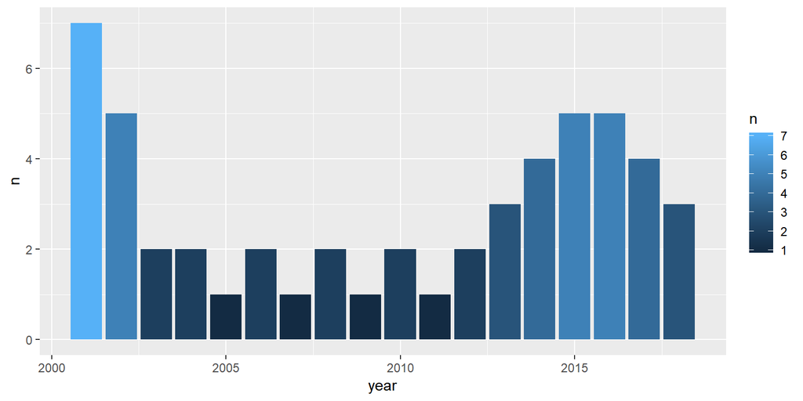

### Current Australian’s in the top 100 ATP Rankings

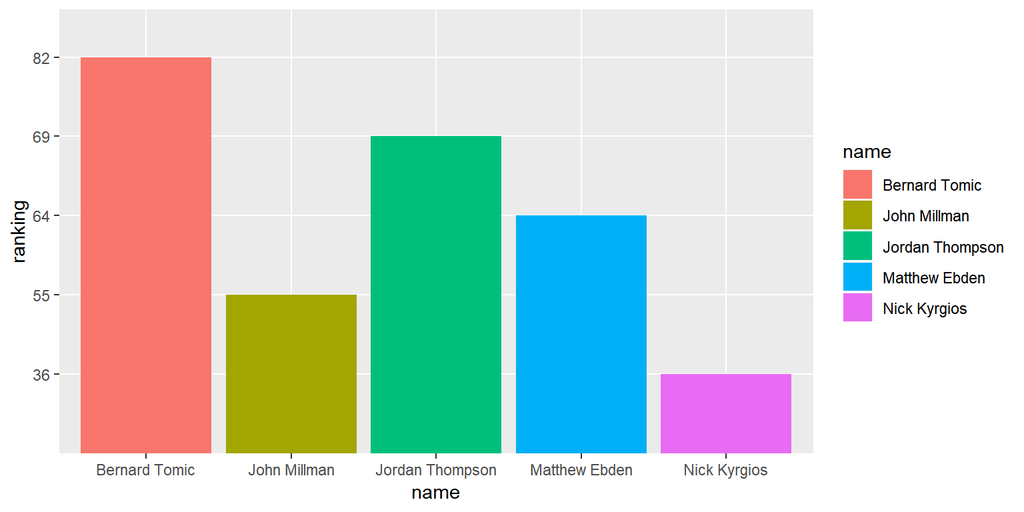

[interactive chart not shown]

[via GIPHY](https://giphy.com/gifs/australianopen-tennis-australian-open-3o7528F6lKNstvlVks)

### Top ten countries with players in the ATP top 100 since 2001

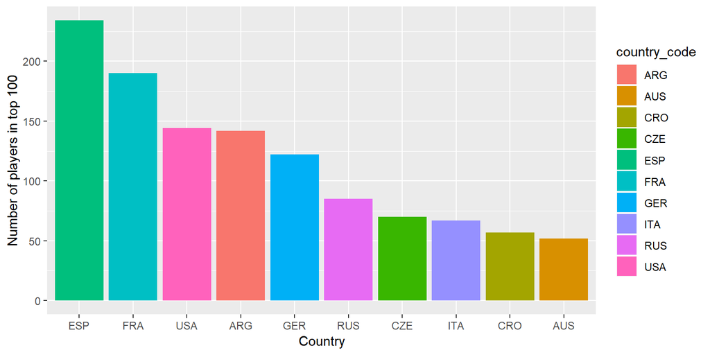

- Spain has had the most players ranked in the top 100 since 2001 with 234 players
- Australia has had the 10th most with 52 players
- 7 of the countries in the top ten are from Europe